# Alternate Advantage/Disadvantage Rolling

Elliott O’Brien

5/19/2020

# BACKGROUND

source: https://fivethirtyeight.com/features/can-you-find-the-best-dungeons-dragons-strategy/

The fifth edition of Dungeons & Dragons introduced a system of “advantage and disadvantage.” When you roll a die “with advantage,” you roll the die twice and keep the higher result. Rolling “with disadvantage” is similar, except you keep the lower result instead. The rules further specify that when a player rolls with both advantage and disadvantage, they cancel out, and the player rolls a single die. Yawn!

There are two other, more mathematically interesting ways that advantage and disadvantage could be combined. First, you could have “advantage of disadvantage,” meaning you roll twice with disadvantage and then keep the higher result. Or, you could have “disadvantage of advantage,” meaning you roll twice with advantage and then keep the lower result. With a fair 20-sided die, which situation produces the highest expected roll: advantage of disadvantage, disadvantage of advantage or rolling a single die?

Extra Credit: Instead of maximizing your expected roll, suppose you need to roll N or better with your 20-sided die. For each value of N, is it better to use advantage of disadvantage, disadvantage of advantage or rolling a single die?

# Simulate the rolls.

```r
set.seed(42)
N <- 2000

roll_table <- tibble(
  roll = sort(c(seq(1, N, 1), seq(1, N, 1)), decreasing = F),
  die_1 = rdunif(2*N, 1, 20),
  die_2 = rdunif(2*N, 1, 20),
  advantage = pmax(die_1, die_2),
  disadvantage = pmin(die_1, die_2)
)

head(roll_table)
```

```
## # A tibble: 6 x 5
##    roll die_1 die_2 advantage disadvantage
##   <dbl> <dbl> <dbl>     <dbl>        <dbl>
## 1     1    17    10        17           10
## 2     1     5    18        18            5
## 3     2     1    15        15            1
## 4     2    10    20        20           10
## 5     3     4    13        13            4
## 6     3    18     2        18            2
```

```r
outcomes_table <- roll_table %>%
  group_by(roll) %>%
  summarize(
    adv_on_disadv = max(disadvantage),
    disadv_on_adv = min(advantage)
  )

head(outcomes_table)
```

```
## # A tibble: 6 x 3
##    roll adv_on_disadv disadv_on_adv
##   <dbl>         <dbl>         <dbl>
## 1     1            10            17
## 2     2            10            15
## 3     3             4            13
## 4     4            17            15
## 5     5             7            11
## 6     6            14             5
```

# Results

Winnder: Disadvantage-on-Advantage

This is counterintuitive, but alas, the data does not lie.

TODO: add a sample size slider to explore the diverging of distributions.

```r
outcomes_table %>%
  summarize(
    adv_on_disadv_mean = mean(adv_on_disadv),
    disadv_on_adv_mean = mean(disadv_on_adv)
  )
```

```
## # A tibble: 1 x 2
##   adv_on_disadv_mean disadv_on_adv_mean
##                <dbl>              <dbl>
## 1               9.91               11.3
```

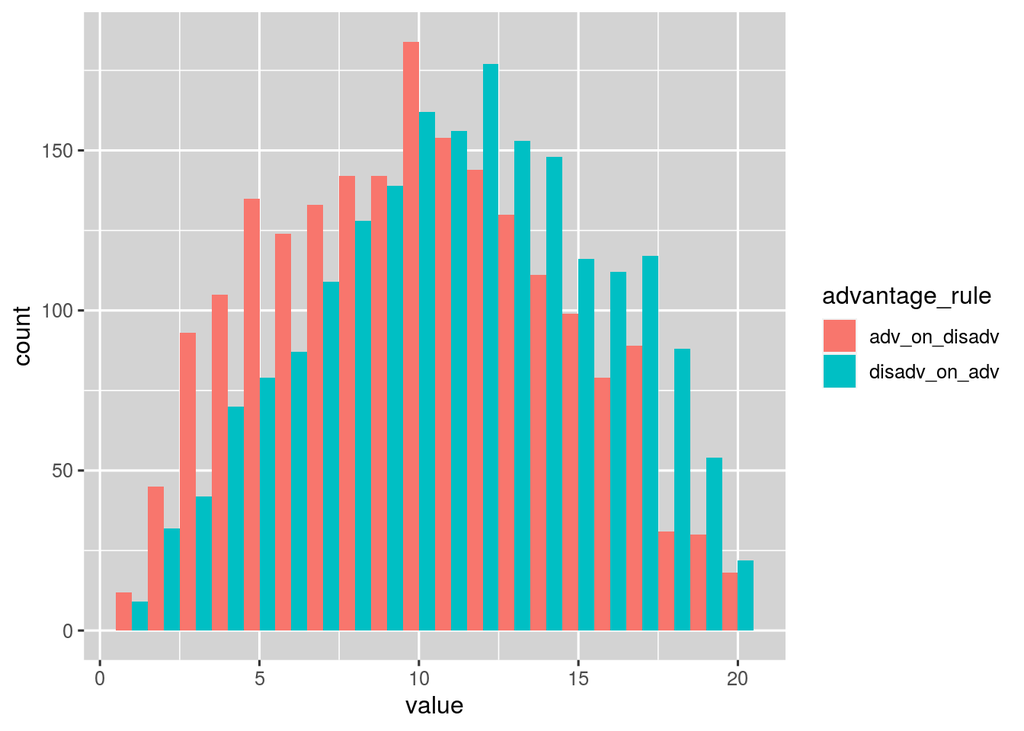

```r
outcomes_table_long <- outcomes_table %>%
  pivot_longer(
    cols = c(adv_on_disadv, disadv_on_adv),
    names_to = 'advantage_rule'
  )

outcomes_table_long %>%
  ggplot() +
  geom_histogram(aes(x=value, fill=advantage_rule), position='dodge', binwidth=1)
```

# Best Strategy by Desired Roll

```r
outcomes_table_long %>%
  group_by(value) %>%
  summarize(
    `% A on D` = mean(advantage_rule == 'adv_on_disadv'),
    `% D on A` = mean(advantage_rule == 'disadv_on_adv'),
    `Dominant Rule` = if_else(`% A on D` > `% D on A`, 'Adv. on Disadv.', 'Disadv. on Adv.')
  ) %>%
  ungroup %>%
  rename(`Required Roll Value` = value) %>%
  kable(digits = 3, caption='Dominant Advantage Rules by Roll Value') %>%
  kable_styling(bootstrap_options = c("striped", "hover", "condensed"), full_width = F)
```

Dominant Advantage Rules by Roll Value

| Required Roll Value | % A on D | % D on A | Dominant Rule |
| --- | --- | --- | --- |
| 1 | 0.571 | 0.429 | Adv. on Disadv. |
| 2 | 0.584 | 0.416 | Adv. on Disadv. |
| 3 | 0.689 | 0.311 | Adv. on Disadv. |
| 4 | 0.600 | 0.400 | Adv. on Disadv. |
| 5 | 0.631 | 0.369 | Adv. on Disadv. |
| 6 | 0.588 | 0.412 | Adv. on Disadv. |
| 7 | 0.550 | 0.450 | Adv. on Disadv. |
| 8 | 0.526 | 0.474 | Adv. on Disadv. |
| 9 | 0.505 | 0.495 | Adv. on Disadv. |
| 10 | 0.532 | 0.468 | Adv. on Disadv. |
| 11 | 0.497 | 0.503 | Disadv. on Adv. |
| 12 | 0.449 | 0.551 | Disadv. on Adv. |
| 13 | 0.459 | 0.541 | Disadv. on Adv. |
| 14 | 0.429 | 0.571 | Disadv. on Adv. |
| 15 | 0.460 | 0.540 | Disadv. on Adv. |
| 16 | 0.414 | 0.586 | Disadv. on Adv. |
| 17 | 0.432 | 0.568 | Disadv. on Adv. |
| 18 | 0.261 | 0.739 | Disadv. on Adv. |
| 19 | 0.357 | 0.643 | Disadv. on Adv. |
| 20 | 0.450 | 0.550 | Disadv. on Adv. |